# Striped Bass: Tag Returns from Sub-Legal at Tagging

## Introduction

In 2010, we began tagging sub-legal sized Striped Bass (i.e., < 42 cm fork length[FL]). Herein, we summarize sub-legal tagging (release) data and return (i.e., angler tag return) data to learn some about catch & release and learn more about this demographic of Striped Bass.

## Catch

Below, we show all Striped Bass caught and measured, less recaptures (i.e., within season and previous seasons). `Count` and `Prop` fields include only measured fish. (`Subs` < 42 cm FL; `Legs` ≥ 42 cm FL)

*Note*: 2018 data are incomplete (i.e., data entry ongoing) and will certainly change

*Note*: data are mostly from fyke trap tagging (in Knights Landing). Since 2010, we’ve tagged only one day using gill nets (2011-Apr-19, where we caught 17 Striped Bass, of which we tagged 16).

*Note*: in 2014 we did not tag Striped Bass

| RelYear | AllCaught | AllMeas | CountSubs | PropSubs | CountLegs | PropLegs |
| --- | --- | --- | --- | --- | --- | --- |
| 2010 | 1823 | 1820 | 396 | 0.21758242 | 1424 | 0.7824176 |
| 2011 | 5708 | 5685 | 2035 | 0.35795954 | 3650 | 0.6420405 |
| 2012 | 6642 | 6624 | 968 | 0.14613527 | 5656 | 0.8538647 |
| 2013 | 2684 | 2616 | 187 | 0.07148318 | 2429 | 0.9285168 |
| 2015 | 478 | 473 | 94 | 0.19873150 | 379 | 0.8012685 |
| 2016 | 4191 | 3694 | 1497 | 0.40525176 | 2197 | 0.5947482 |
| 2017 | 5519 | 5400 | 2375 | 0.43981481 | 3025 | 0.5601852 |
| 2018 | 2019 | 2014 | 643 | 0.31926514 | 1371 | 0.6807349 |

Here we present length-frequency distributions by year. Number represents the number of sub-legal Striped Bass caught and measured.

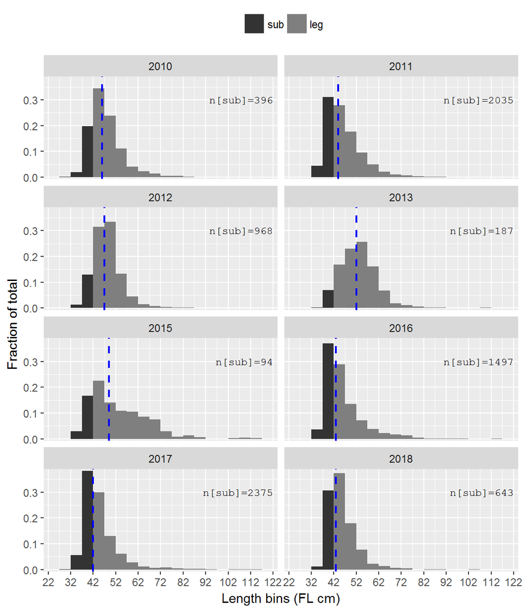

## Tagged Fish

For only fish that were tagged (where field `TagAction` = 1), below are the count & proportions of sublegals (based on what was measured) along with some descriptive stats.

| RelYear | AllTagged | CountSubs | PropSubs | MinSubLen | MaxSubLen | AvgSubLen | SdSubLen |
| --- | --- | --- | --- | --- | --- | --- | --- |
| 2010 | 1823 | 396 | 0.21758242 | 31 | 41 | 39.19697 | 1.838158 |
| 2011 | 4597 | 1588 | 0.34596950 | 32 | 41 | 38.80982 | 1.827220 |
| 2012 | 3913 | 563 | 0.14391616 | 30 | 41 | 38.95204 | 1.762452 |
| 2013 | 2634 | 187 | 0.07148318 | 34 | 41 | 39.48663 | 1.471442 |
| 2015 | 470 | 91 | 0.19402985 | 35 | 41 | 38.74725 | 1.859471 |
| 2016 | 1904 | 746 | 0.39242504 | 32 | 41 | 38.95442 | 1.827622 |
| 2017 | 2913 | 1361 | 0.46914857 | 31 | 41 | 38.52461 | 1.876210 |
| 2018 | 2019 | 643 | 0.31926514 | 31 | 41 | 39.45412 | 1.473228 |

## Tag Returns

Note: As data entry for 2018 is currently ongoing, we have not yet processed 2018 tag returns. But to date, we have received 10 returns from 2018 tagged fish.

Angler tag returns (of Striped Bass < 42 cm FL at tagging) for each release year (`Year`) by return year (`First`: caught within 365 days of tagging date; `Second`: caught between 365 and 730 days of tagging date; `Third+`: everything else beyond 730 days)

| Year | First | Second | Third+ |
| --- | --- | --- | --- |
| 2010 | 2 | 1 | 1 |
| 2011 | 22 | 10 | 2 |
| 2012 | 7 | 1 | 1 |
| 2013 | 4 | 1 | 0 |
| 2015 | 1 | 0 | 0 |
| 2016 | 6 | 8 | 0 |
| 2017 | 29 | 3 | 0 |

Angler tag returns (of Striped Bass < 42 cm FL at tagging) for each release year (`Year`) by fate (`K`: kept; `R`: released; `U`: unknown, angler did not supply info)

| Year | K | R | U |
| --- | --- | --- | --- |
| 2010 | 1 | 0 | 3 |
| 2011 | 10 | 13 | 11 |
| 2012 | 3 | 3 | 3 |
| 2013 | 1 | 3 | 1 |
| 2015 | 0 | 1 | 0 |
| 2016 | 5 | 7 | 2 |
| 2017 | 17 | 11 | 4 |

```
##       ReturnLengthNA
## Year   FALSE TRUE
##   2010     1    3
##   2011    27    7
##   2012     9    0
##   2013     3    2
##   2015     0    1
##   2016    13    1
##   2017    28    4
```

Figure shows angler reported length (inches) ~ fish length at tagged. Fish where no length reported by angler are not included in the figure below (see `TRUE` field in table above, 18 in total).

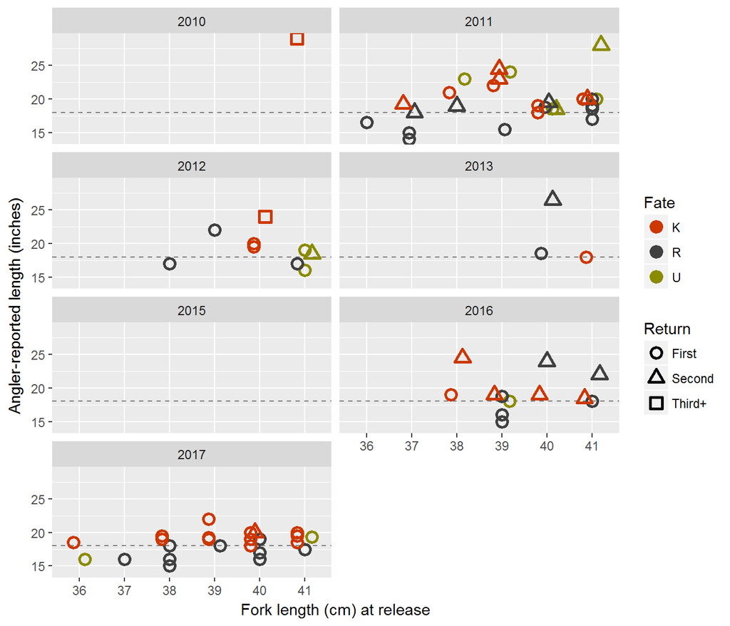

## Analytics

Here, we show some “quick-n-dirty” analyes using angler tag returns (returns) and CDFW tag recaptures (recaptures). Again, we’ve constrained the size limit to sub-legal (i.e., fork length < 42 cm) **at** tagging.

We estimate survival rate, abundance, and catch & release rate according to the sections below. The table below shows (by release year, `RelYear`) count of returns, recaptures, and CDFW tag releases. Metadata (i.e., field descriptions) are provided below the table.

| RelYear | M1 | C1 | R11k | R11r | R11u | M2 | R12 | R22 | RR |
| --- | --- | --- | --- | --- | --- | --- | --- | --- | --- |
| 2010 | 396 | 396 | NA | NA | 2 | 1588 | 1 | 22 | 0 |
| 2011 | 1588 | 2035 | 5 | 10 | 7 | 563 | 10 | 7 | 0 |
| 2012 | 563 | 968 | 2 | 3 | 2 | 187 | 1 | 4 | 2 |
| 2013 | 187 | 187 | 1 | 2 | 1 | NA | 1 | NA | 1 |
| 2014 | NA | NA | NA | NA | NA | 91 | NA | 1 | 0 |
| 2015 | 91 | 94 | NA | 1 | NA | 746 | NA | 6 | 0 |
| 2016 | 746 | 1497 | 1 | 4 | 1 | 1361 | 8 | 29 | 3 |
| 2017 | 1361 | 2375 | 16 | 10 | 3 | 643 | 3 | NA | 14 |
| 2018 | 643 | 643 | NA | NA | NA | NA | NA | NA | 0 |

Metadata provided for reference.

| RelYear | release or tagging year |
| --- | --- |
| M1 | fish tagged in release year |
| C1 | fish caught in release year, includes tagged fish (M1) but not recaptures |
| R11k | first-year tag returns from release year (fate: kept, released, unknown) |
| R11r | see R11k |
| R11u | see R11k |
| M2 | fish tagged in release year + 1 |
| R12 | second-year tag returns from release year |
| R22 | first-year tag returns from release year + 1 |
| RR | CDFW within-season recaptures |

#### Survival

| RelYear | SurvEst |
| --- | --- |
| 2010 | 0.1822773 |
| 2011 | 0.5064772 |
| 2012 | 0.0830373 |
| 2013 | NA |
| 2014 | NA |
| 2015 | NA |
| 2016 | 0.5032819 |
| 2017 | NA |
| 2018 | NA |

#### Adundance

$\hat{N}=\frac{M1\times(C1+1)}{RR+1}$

| RelYear | AbundEst |
| --- | --- |
| 2010 | 157212.0 |
| 2011 | 3233168.0 |
| 2012 | 181849.0 |
| 2013 | 17578.0 |
| 2014 | NA |
| 2015 | 8645.0 |
| 2016 | 279377.0 |
| 2017 | 215582.4 |
| 2018 | 414092.0 |

#### Catch & Release

```
## [1]  2 22  7  4  0  1  6 29  0
```

| R11k | R11r | R11u |
| --- | --- | --- |
| NA | NA | 2 |
| 5 | 10 | 7 |
| 2 | 3 | 2 |
| 1 | 2 | 1 |
| NA | NA | NA |
| NA | 1 | NA |
| 1 | 4 | 1 |
| 16 | 10 | 3 |
| NA | NA | NA |

```
##            R11k      R11r      R11u
##  [1,]        NA        NA        NA
##  [2,] 0.2272727 0.4545455 0.3181818
##  [3,] 0.2857143 0.4285714 0.2857143
##  [4,] 0.2500000 0.5000000 0.2500000
##  [5,]        NA        NA        NA
##  [6,]        NA        NA        NA
##  [7,] 0.1666667 0.6666667 0.1666667
##  [8,] 0.5517241 0.3448276 0.1034483
##  [9,]        NA        NA        NA
```

CDFW, SportFish Unit  
ran: 2018-06-14 14:10:55